# MoneyBball

Daines

4/24/2021

This project is inspired by Moneyball: The Art of Winning an Unfair Game, a book by Michael Lewis, published in 2003, about the Oakland Athletics baseball team and its general manager Billy Beane. Its focus is the team’s analytical, evidence-based, sabermetric approach to assembling a competitive baseball team despite Oakland’s small budget. (Source: https://en.wikipedia.org/wiki/Moneyball)

### Can this be replicated in basketball?

Could data analytics be applied to NBA player statistics to assemble a competitive team on a small budget?

### Data Sources

- NBA Salaries - USA Today Sports - https://hoopshype.com/salaries/
- NBA Team Salaries - USA Today Sports - https://hoopshype.com/salaries/
- NBA Players Statistics - NBA.com - https://www.nba.com/stats/players

### Loading Salary Data

#### Cleaning Data

- Load from csv file
- Remove unneeded columns
- Rename columns
- Remove header row from source data
- Convert salary ($,) from chr to numeric
- Sort by player name (to later combine with statistics)

Here is a boxplot of player salaries:

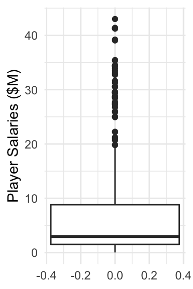

Search for your favorite NBA player to see how much money they are being paid per yer. Some of these might surprise you.

| Player | Salary.20.21 |
| --- | --- |
| Aaron Gordon | 18136364 |
| Aaron Holiday | 2345640 |
| Aaron Nesmith | 3458400 |
| Abdel Nader | 1752950 |
| Adam Mokoka | 449115 |
| Admiral Schofield | 1517981 |
| AJ Hammons | 350087 |
| Al Horford | 27500000 |
| Al-Farouq Aminu | 9720900 |
| Alec Burks | 6000000 |

[output cut: 559 more lines]

This shows boxplot of team salaries:

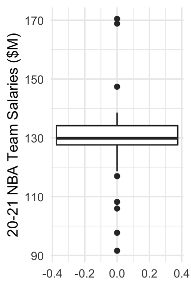

As depicted in boxplot, the salaries are grouped around $130M. Yet, for approximately the same team salary there is a wide range of wins (from <15 to >40)!

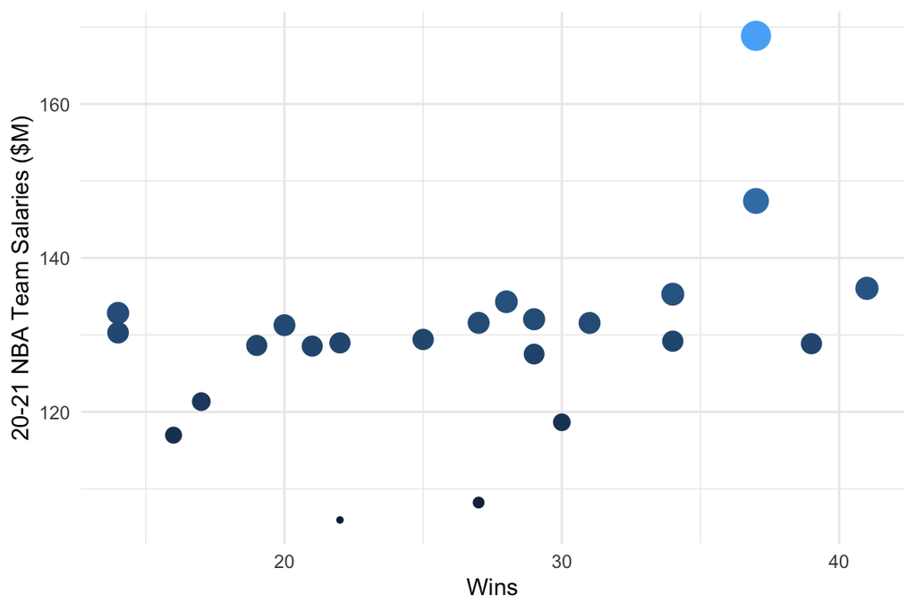

### Loading Player Statistics Data

#### Player Statistics Data

```
## [1] "46 Statistics for 520 Players have been loaded."
```

#### Analyzing Net Rating vs. Salary

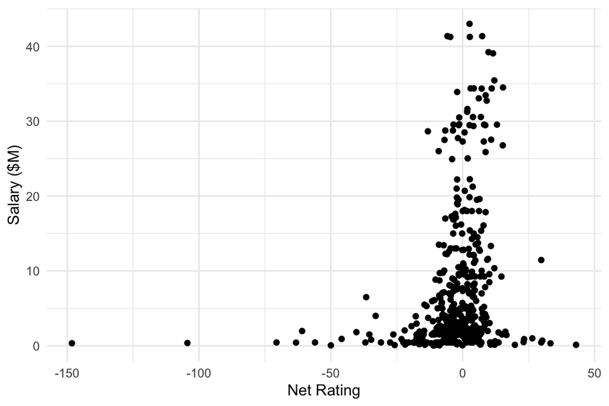

#### Analyzing +/- vs. Salary

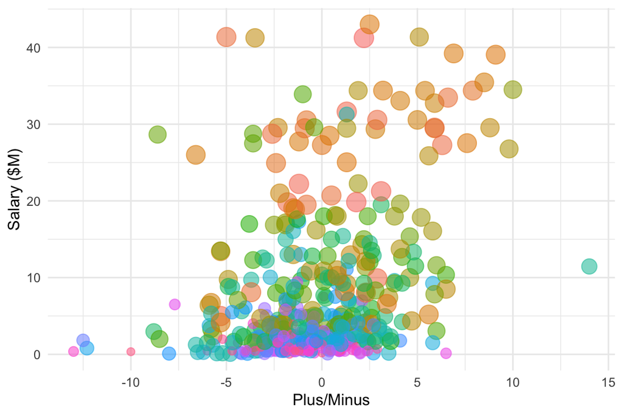

#### Let’s filter out players

```
## [1] "Now we have 15 players to analyze."
```

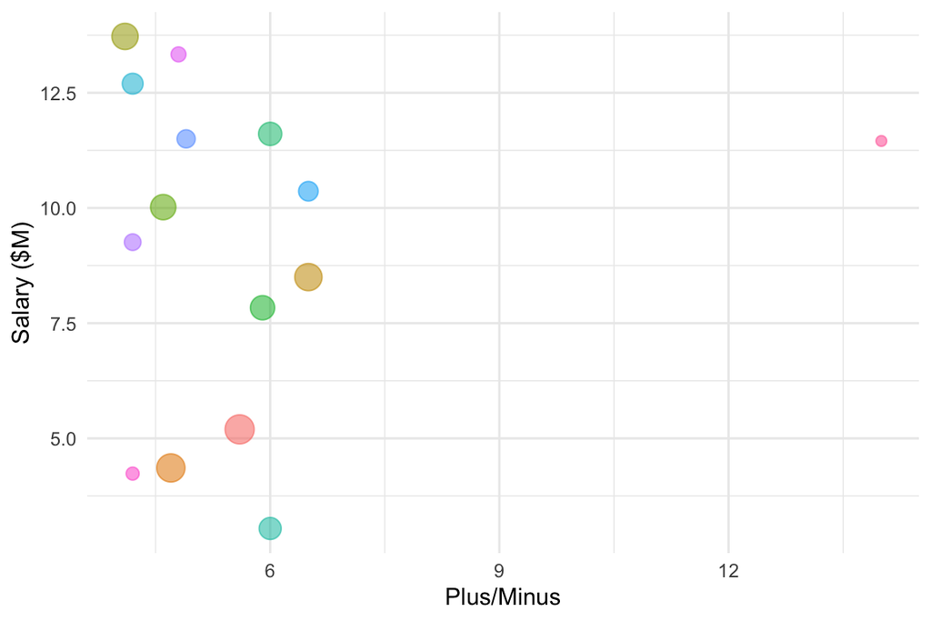

```
##               Player P.M   Salary
## 1         Seth Curry 5.9  7834449
## 2    Cameron Johnson 4.2  4235160
## 3      Mikal Bridges 4.7  4359000
## 4   Donovan Mitchell 5.6  5195501
## 5        Brook Lopez 4.2 12697675
## 6      Nicolas Batum   6 11608231
## 7      Royce O'Neale 6.5  8500000
## 8      Deandre Ayton 4.6 10018200
## 9        Serge Ibaka 4.2  9258000
## 10 Spencer Dinwiddie  14 11454048
## 11        Joe Ingles 6.5 10363637
## 12   Jordan Clarkson 4.9 11500000
## 13  Donte DiVincenzo   6  3044160
## 14  Patrick Beverley 4.8 13333333
## 15       Will Barton 4.1 13723214
```

```
## [1] 137124608
```